# TP3: Variable and model selection — Correction

Author

Lionel Hertzog

Published

September 11, 2026

## 0.1 Read the data

```r
library(tidyverse)
library(MASS)
library(glmnet)
library(ggeffects)
library(ggdag)

dat_tp3 <- read.csv("../data/dat_tp3.csv")

glimpse(dat_tp3)
```

```
Rows: 1,515
Columns: 44
$ idp                   <int> 746162, 712867, 720620, 770767, 751199, 740332, …
$ mqd                   <dbl> 0.3446880, 0.2135135, 0.2213249, 0.1574642, 0.31…
$ biomass               <dbl> 348.55178, 238.30077, 134.87458, 117.60808, 74.8…
$ zp                    <int> 332, 348, 359, 374, 466, 384, 445, 507, 295, 417…
$ reserutile            <dbl> 89.50, 63.00, 35.00, 50.40, 21.00, 29.40, 108.00…
$ troph_r               <dbl> 2.980770, 1.114240, 4.049550, 1.187790, 2.375920…
$ species               <chr> "Pin sylvestre", "Sapin pectiné", "Sapin pectiné…
$ ownership             <chr> "Forêts domaniales RF", "Autres forêts publiques…
$ tmoy_win_mean_anomaly <dbl> 0.2279420, 0.1997101, 0.2016412, 0.1916645, 0.19…
$ tmoy_win_min_anomaly  <dbl> -1.563275, -1.639084, -1.534730, -1.610424, -1.5…
$ tmoy_win_max_anomaly  <dbl> 2.335507, 2.348159, 2.319651, 2.388014, 2.378660…
$ tmoy_spr_mean_anomaly <dbl> 0.2006629, 0.2062061, 0.1944872, 0.2004970, 0.20…
$ tmoy_spr_min_anomaly  <dbl> -1.796824, -1.794088, -1.830551, -1.827319, -1.8…
```

[output cut: 31 more lines]

```r
summary(dat_tp3)
```

```
      idp               mqd             biomass              zp
 Min.   : 500002   Min.   :0.07639   Min.   :  0.498   Min.   : 185.0
 1st Qu.: 711505   1st Qu.:0.18933   1st Qu.:144.201   1st Qu.: 409.5
 Median : 915670   Median :0.25604   Median :227.235   Median : 561.0
 Mean   : 914832   Mean   :0.27158   Mean   :236.312   Mean   : 587.3
 3rd Qu.:1118223   3rd Qu.:0.33295   3rd Qu.:312.398   3rd Qu.: 743.5
 Max.   :1354500   Max.   :0.75211   Max.   :820.076   Max.   :1290.0

   reserutile        troph_r         species           ownership
 Min.   :  0.00   Min.   :0.4626   Length:1515        Length:1515
 1st Qu.: 33.60   1st Qu.:1.6275   Class :character   Class :character
 Median : 50.40   Median :2.4470   Mode  :character   Mode  :character
 Mean   : 57.06   Mean   :2.8532
 3rd Qu.: 72.75   3rd Qu.:3.7432
 Max.   :175.50   Max.   :8.7154
                  NA's   :1
 tmoy_win_mean_anomaly tmoy_win_min_anomaly tmoy_win_max_anomaly
 Min.   :-0.1033       Min.   :-3.158       Min.   :1.520
 1st Qu.: 0.1685       1st Qu.:-1.749       1st Qu.:2.315
 Median : 0.3782       Median :-1.564       Median :2.456
 Mean   : 0.3875       Mean   :-1.608       Mean   :2.435
 3rd Qu.: 0.6068       3rd Qu.:-1.458       3rd Qu.:2.638
 Max.   : 0.7889       Max.   :-1.277       Max.   :2.950

 tmoy_spr_mean_anomaly tmoy_spr_min_anomaly tmoy_spr_max_anomaly
 Min.   :0.06962       Min.   :-2.214       Min.   :1.560
 1st Qu.:0.21625       1st Qu.:-1.799       1st Qu.:1.784
 Median :0.26663       Median :-1.647       Median :1.844
 Mean   :0.26366       Mean   :-1.630       Mean   :1.825
 3rd Qu.:0.30640       3rd Qu.:-1.443       3rd Qu.:1.883
 Max.   :0.40893       Max.   :-1.217       Max.   :2.049

 tmoy_sum_mean_anomaly tmoy_sum_min_anomaly tmoy_sum_max_anomaly
 Min.   :-0.2391       Min.   :-2.3184      Min.   :1.823
 1st Qu.: 0.4577       1st Qu.:-0.8057      1st Qu.:2.129
 Median : 0.7926       Median :-0.7311      Median :2.193
 Mean   : 0.7278       Mean   :-0.6998      Mean   :2.196
 3rd Qu.: 0.9819       3rd Qu.:-0.5549      3rd Qu.:2.266
 Max.   : 1.2089       Max.   :-0.1595      Max.   :2.541

```

[output cut: 40 more lines]

```
 spei17.13_mean    spei18.13_mean    spei19.13_mean    spei20.13_mean
 Min.   :-1.5900   Min.   :-1.6015   Min.   :-1.6130   Min.   :-1.6241
 1st Qu.:-0.9504   1st Qu.:-0.9577   1st Qu.:-0.9696   1st Qu.:-0.9791
 Median :-0.6053   Median :-0.6156   Median :-0.6245   Median :-0.6315
 Mean   :-0.6727   Mean   :-0.6780   Mean   :-0.6830   Mean   :-0.6888
 3rd Qu.:-0.3601   3rd Qu.:-0.3585   3rd Qu.:-0.3579   3rd Qu.:-0.3584
 Max.   : 0.4394   Max.   : 0.4530   Max.   : 0.4653   Max.   : 0.4767

 spei21.13_mean    spei22.13_mean    spei23.13_mean    spei24.13_mean
 Min.   :-1.6330   Min.   :-1.6429   Min.   :-1.6530   Min.   :-1.6598
 1st Qu.:-0.9902   1st Qu.:-1.0023   1st Qu.:-1.0139   1st Qu.:-1.0215
 Median :-0.6420   Median :-0.6529   Median :-0.6616   Median :-0.6707
 Mean   :-0.6973   Mean   :-0.7040   Mean   :-0.7126   Mean   :-0.7194
 3rd Qu.:-0.3658   3rd Qu.:-0.3701   3rd Qu.:-0.3725   3rd Qu.:-0.3797
 Max.   : 0.4872   Max.   : 0.5016   Max.   : 0.5114   Max.   : 0.5186
```

```r
dat_tp3 <- na.omit(dat_tp3)
```

There are 1515 plots and 44 variables. There is one missing value for `troph_r`; the other variables are complete.

# 1 Prediction

## 1.1 AIC

### 1.1.1 1. Scale all continuous variables

```r
climate_vars <- names(dat_tp3)[
  grepl("^tmoy_", names(dat_tp3)) |
  grepl("^spei", names(dat_tp3))
]

vars_to_scale <- c("troph_r", "mqd", "zp", climate_vars)

dat <- dat_tp3 %>%
  mutate(across(all_of(vars_to_scale), ~ as.numeric(scale(.x))))
```

### 1.1.2 2. Fit the full model

```r
dat_mod <- dat %>%
  dplyr::select(biomass, troph_r, mqd, ownership, zp, all_of(climate_vars))

mod_full <- lm(biomass ~ ., data = dat_mod)

summary(mod_full)
```

```
Call:
lm(formula = biomass ~ ., data = dat_mod)

Residuals:
    Min      1Q  Median      3Q     Max
-401.21  -79.04   -5.06   67.08  529.68

Coefficients:
                                               Estimate Std. Error t value
(Intercept)                                    234.3853     4.9837  47.031
troph_r                                         19.1067     3.4360   5.561
mqd                                             61.7485     3.0434  20.289
ownershipForêts domaniales RF                   -6.1600     7.9773  -0.772
ownershipForêts privées et autres - En PSG      -6.4272    11.4390  -0.562
ownershipForêts privées et autres - Hors PSG    17.8359     8.3435   2.138
zp                                              -3.4829     8.9836  -0.388
tmoy_win_mean_anomaly                           10.9367    26.4472   0.414
tmoy_win_min_anomaly                            -4.8887     7.3069  -0.669
tmoy_win_max_anomaly                            -4.9565     8.0441  -0.616
tmoy_spr_mean_anomaly                           -3.5341    14.9334  -0.237
tmoy_spr_min_anomaly                            15.0112    15.0237   0.999
tmoy_spr_max_anomaly                            -2.7893     6.9809  -0.400
tmoy_sum_mean_anomaly                            0.1482    29.2783   0.005
tmoy_sum_min_anomaly                            -5.9910    11.3466  -0.528
tmoy_sum_max_anomaly                             0.5829     5.5070   0.106
tmoy_aut_mean_anomaly                           -0.6589    14.9763  -0.044
tmoy_aut_min_anomaly                            -3.6510    12.3754  -0.295
tmoy_aut_max_anomaly                             5.0409     9.8180   0.513
spei1.13_mean                                  -80.7364    93.8130  -0.861
spei2.13_mean                                  104.5236   257.6487   0.406
spei3.13_mean                                  191.6602   386.0641   0.496
spei4.13_mean                                  -94.1440   455.0073  -0.207
spei5.13_mean                                 -338.3631   668.2119  -0.506
spei6.13_mean                                  968.9834   800.7832   1.210
spei7.13_mean                                -1805.3574   962.7615  -1.875
spei8.13_mean                                  219.4374  1254.0783   0.175
spei9.13_mean                                 1697.3953  1475.2312   1.151
spei10.13_mean                               -1951.1119  1376.1091  -1.418
spei11.13_mean                                2716.3603  1278.7641   2.124
spei12.13_mean                               -1984.5543  1812.0364  -1.095
```

[output cut: 47 more lines]

```
spei16.13_mean                                 0.4029
spei17.13_mean                                 0.3831
spei18.13_mean                                 0.6291
spei19.13_mean                                 0.4023
spei20.13_mean                                 0.0771 .
spei21.13_mean                                 0.2397
spei22.13_mean                                 0.2283
spei23.13_mean                                 0.1339
spei24.13_mean                                 0.4024
---
Signif. codes:  0 '***' 0.001 '**' 0.01 '*' 0.05 '.' 0.1 ' ' 1

Residual standard error: 113.8 on 1471 degrees of freedom
Multiple R-squared:  0.275, Adjusted R-squared:  0.2543
F-statistic: 13.29 on 42 and 1471 DF,  p-value: < 2.2e-16
```

### 1.1.3 3. Stepwise AIC selection

```r
mod_aic <- stepAIC(mod_full, direction = "both", trace = FALSE)

summary(mod_aic)
```

```
Call:
lm(formula = biomass ~ troph_r + mqd + ownership + tmoy_win_mean_anomaly +
    tmoy_sum_min_anomaly + spei2.13_mean + spei7.13_mean + spei9.13_mean +
    spei10.13_mean + spei11.13_mean + spei14.13_mean + spei20.13_mean +
    spei22.13_mean + spei23.13_mean, data = dat_mod)

Residuals:
    Min      1Q  Median      3Q     Max
-393.28  -78.92   -5.38   66.27  529.82

Coefficients:
                                              Estimate Std. Error t value
(Intercept)                                    233.862      4.831  48.407
troph_r                                         19.566      3.192   6.129
mqd                                             61.722      2.980  20.713
ownershipForêts domaniales RF                   -5.442      7.589  -0.717
ownershipForêts privées et autres - En PSG      -5.814     11.037  -0.527
ownershipForêts privées et autres - Hors PSG    18.903      7.951   2.377
tmoy_win_mean_anomaly                           12.331      5.590   2.206
tmoy_sum_min_anomaly                            -9.193      4.805  -1.913
spei2.13_mean                                   60.796     37.411   1.625
spei7.13_mean                                 -657.623    266.446  -2.468
spei9.13_mean                                 1756.156    749.217   2.344
spei10.13_mean                               -2113.914    861.418  -2.454
spei11.13_mean                                1386.949    536.959   2.583
spei14.13_mean                                -732.592    221.302  -3.310
spei20.13_mean                                1959.292    520.902   3.761
spei22.13_mean                               -3738.139   1218.814  -3.067
spei23.13_mean                                2080.780    781.313   2.663
                                             Pr(>|t|)
(Intercept)                                   < 2e-16 ***
troph_r                                      1.13e-09 ***
mqd                                           < 2e-16 ***
ownershipForêts domaniales RF                0.473473
ownershipForêts privées et autres - En PSG   0.598421
ownershipForêts privées et autres - Hors PSG 0.017562 *
tmoy_win_mean_anomaly                        0.027530 *
tmoy_sum_min_anomaly                         0.055934 .
spei2.13_mean                                0.104359
spei7.13_mean                                0.013693 *
spei9.13_mean                                0.019209 *
spei10.13_mean                               0.014241 *
spei11.13_mean                               0.009890 **
spei14.13_mean                               0.000954 ***
spei20.13_mean                               0.000176 ***
spei22.13_mean                               0.002201 **
spei23.13_mean                               0.007824 **
---
Signif. codes:  0 '***' 0.001 '**' 0.01 '*' 0.05 '.' 0.1 ' ' 1

Residual standard error: 113.3 on 1497 degrees of freedom
Multiple R-squared:  0.2691,    Adjusted R-squared:  0.2613
F-statistic: 34.45 on 16 and 1497 DF,  p-value: < 2.2e-16
```

### 1.1.4 4. Selected variables and fitted relationships

The variables retained by the stepwise AIC procedure are:

- `troph_r`
- `mqd`
- `ownership`
- `tmoy_win_mean_anomaly`
- `tmoy_sum_min_anomaly`
- `spei2-13_mean`
- `spei7-13_mean`
- `spei9-13_mean`
- `spei10-13_mean`
- `spei11-13_mean`
- `spei14-13_mean`
- `spei20-13_mean`
- `spei22-13_mean`
- `spei23-13_mean`

Some fitted relationships can be plotted with:

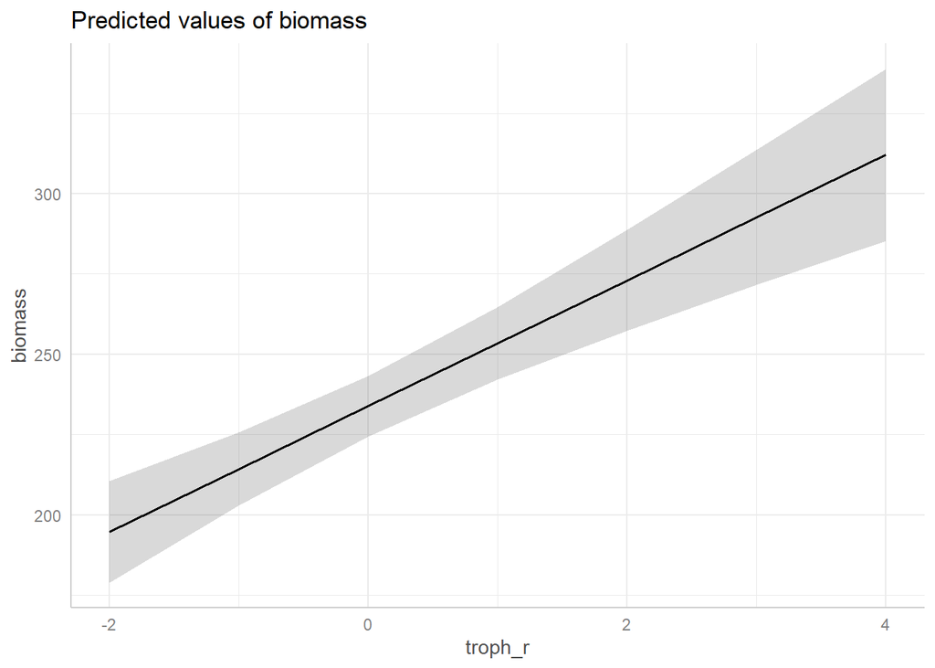

```r
predict_response(mod_aic, terms = "troph_r") %>%
  plot()
```

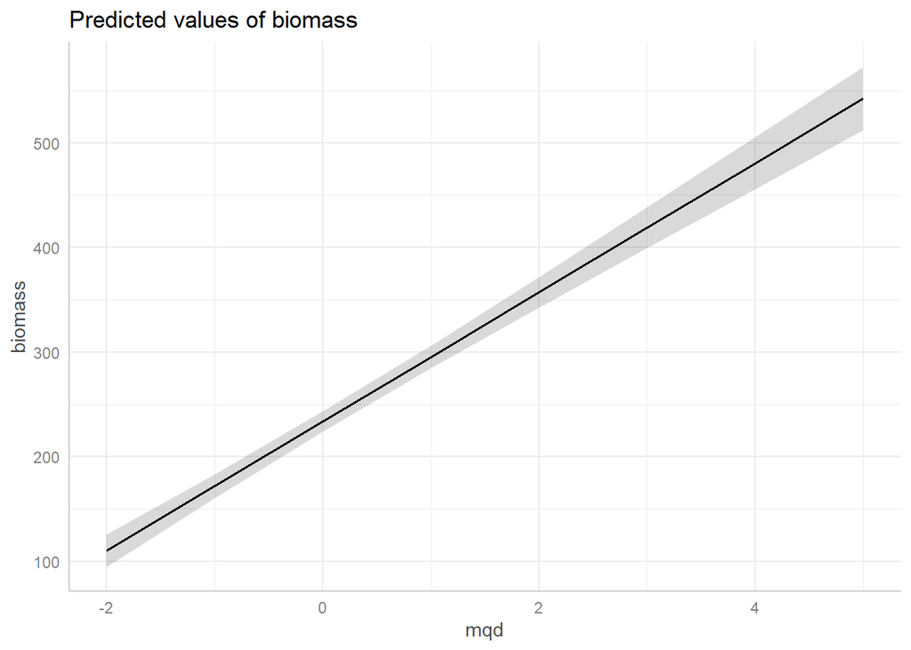

```r
predict_response(mod_aic, terms = "mqd") %>%
  plot()
```

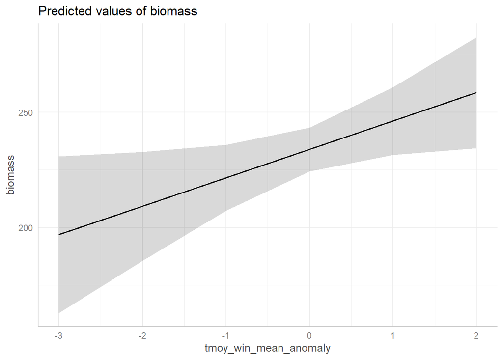

```r
predict_response(mod_aic, terms = "tmoy_win_mean_anomaly") %>%
  plot()
```

The climate variables are strongly correlated with each other, so the individual fitted relationships are difficult to interpret and some have implausibly large slopes. This is a consequence of collinearity among the climate variables.

### 1.1.5 5. Predicted versus observed biomass

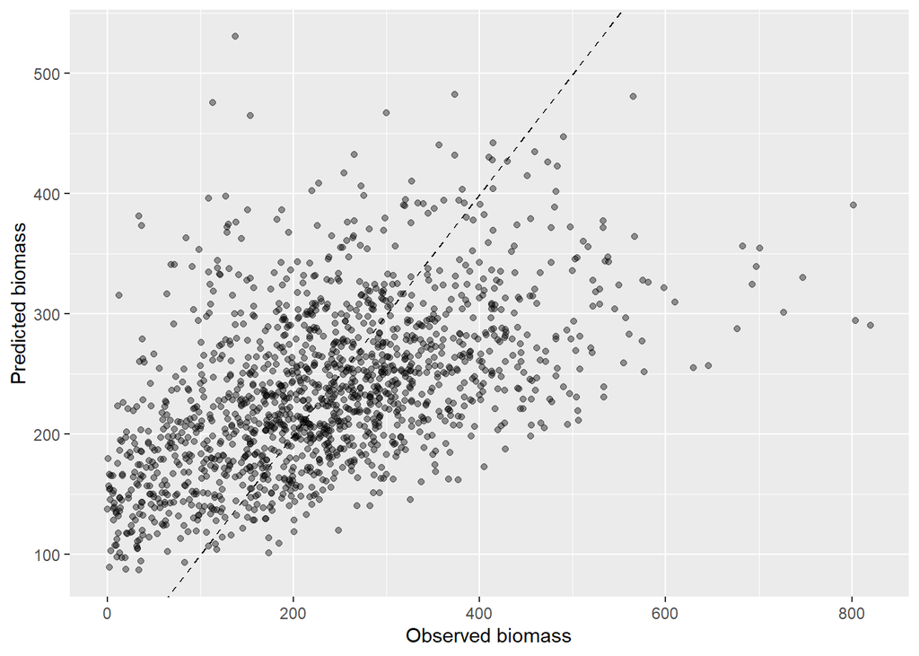

```r
dat_pred <- dat_mod %>%
  mutate(
    observed = biomass,
    predicted = predict(mod_aic)
  )

ggplot(dat_pred, aes(x = observed, y = predicted)) +
  geom_point(alpha = 0.4) +
  geom_abline(intercept = 0, slope = 1, linetype = 2) +
  labs(x = "Observed biomass",
       y = "Predicted biomass")
```

The predictions show a positive relationship with observations, but there is substantial scatter around the 1:1 line. The model explains about 27% of the variance in biomass.

## 1.2 LASSO

### 1.2.1 1. Create `x` and `y`

```r
x <- model.matrix(
  biomass ~ troph_r + mqd + ownership + zp + .,
  data = dat_mod
)[, -1]

y <- dat_mod$biomass
```

### 1.2.2 2. Fit the LASSO model

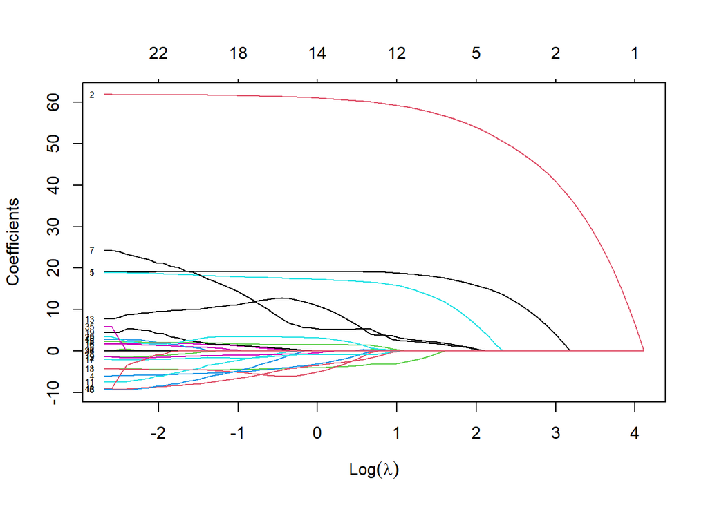

```r
lasso <- glmnet(x, y, alpha = 1)

plot(lasso, xvar = "lambda", label = TRUE, sign.lambda = 1)
```

### 1.2.3 3. Interpret the coefficient path

As `lambda` increases, the penalty becomes stronger and more coefficients are shrunk towards zero. Variables whose coefficients reach zero are removed from the model.

### 1.2.4 4. Cross-validation

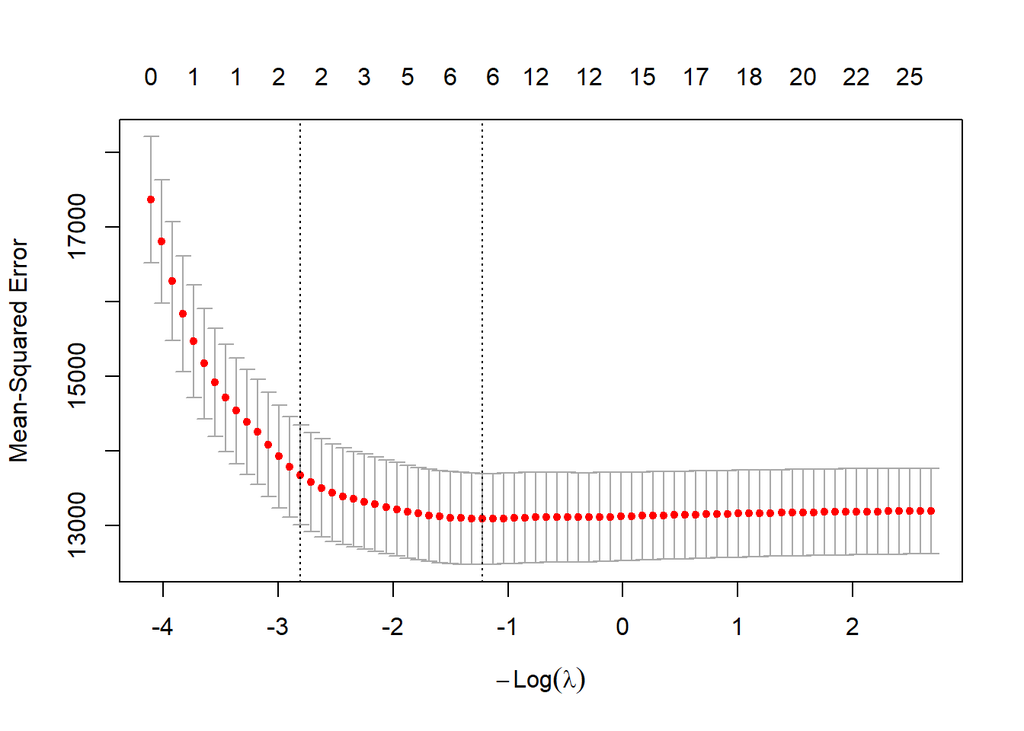

```r
lasso_cv <- cv.glmnet(x, y)

plot(lasso_cv)
```

```r
lambda.opt <- lasso_cv$lambda.1se
lambda.opt
```

```
[1] 16.55623
```

The model selected using `lambda.1se` retains:

```r
coef_opt <- coef(lasso_cv, s = "lambda.1se")

selected_lasso <- rownames(coef_opt)[
  as.vector(coef_opt != 0)
]

selected_lasso
```

```
[1] "(Intercept)" "troph_r"     "mqd"
```

The selected variables are **`troph_r` and `mqd`**.

### 1.2.5 5. Predicted versus observed biomass

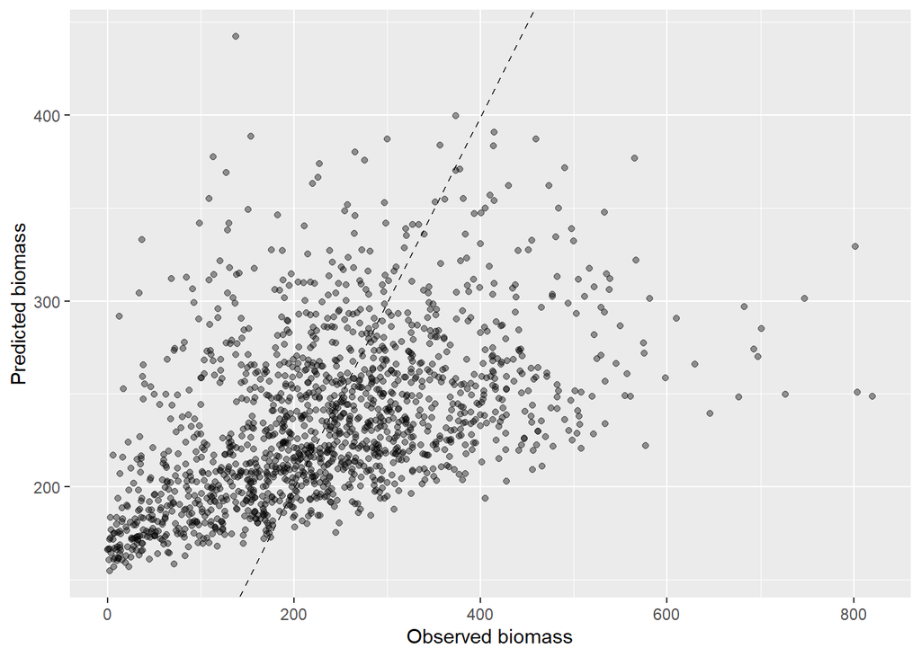

```r
pred_lasso <- as.numeric(
  predict(lasso_cv, newx = x, s = "lambda.1se")
)

ggplot(data.frame(observed = y, predicted = pred_lasso),
       aes(x = observed, y = predicted)) +
  geom_point(alpha = 0.4) +
  geom_abline(intercept = 0, slope = 1, linetype = 2) +
  labs(x = "Observed biomass",
       y = "Predicted biomass")
```

The LASSO predictions are slightly less accurate than the stepAIC predictions on these data, but the model is much more parsimonious. The main variables retained are `troph_r` and `mqd`.

# 2 Understanding

## 2.1 1. Univariate model

```r
mod_1 <- lm(biomass ~ troph_r, data = dat_tp3)

summary(mod_1)
```

```
Call:
lm(formula = biomass ~ troph_r, data = dat_tp3)

Residuals:
    Min      1Q  Median      3Q     Max
-302.46  -93.79   -5.34   80.02  550.10

Coefficients:
            Estimate Std. Error t value Pr(>|t|)
(Intercept)  192.379      6.897  27.894  < 2e-16 ***
troph_r       15.405      2.117   7.279  5.4e-13 ***
---
Signif. codes:  0 '***' 0.001 '**' 0.01 '*' 0.05 '.' 0.1 ' ' 1

Residual standard error: 129.6 on 1512 degrees of freedom
Multiple R-squared:  0.03385,   Adjusted R-squared:  0.03321
F-statistic: 52.98 on 1 and 1512 DF,  p-value: 5.396e-13
```

Thus, biomass increases by approximately 15.4 units for a one-unit increase in `troph_r`.

## 2.2 2. Add `mqd`

```r
mod_2 <- lm(biomass ~ troph_r + mqd, data = dat_tp3)

summary(mod_2)
```

```
Call:
lm(formula = biomass ~ troph_r + mqd, data = dat_tp3)

Residuals:
    Min      1Q  Median      3Q     Max
-407.86  -78.34   -7.57   64.04  547.90

Coefficients:
            Estimate Std. Error t value Pr(>|t|)
(Intercept)   44.354      9.404   4.716 2.62e-06 ***
troph_r       15.245      1.870   8.154 7.29e-16 ***
mqd          546.645     26.458  20.661  < 2e-16 ***
---
Signif. codes:  0 '***' 0.001 '**' 0.01 '*' 0.05 '.' 0.1 ' ' 1

Residual standard error: 114.5 on 1511 degrees of freedom
Multiple R-squared:  0.2467,    Adjusted R-squared:  0.2457
F-statistic: 247.4 on 2 and 1511 DF,  p-value: < 2.2e-16
```

```r
cor(dat_tp3$troph_r, dat_tp3$mqd, use = "complete.obs")
```

```
[1] 0.004146869
```

The estimated coefficients are approximately:

- `troph_r`: 15.25
- `mqd`: 546.65

The correlation between `troph_r` and `mqd` is approximately **0.004**, i.e. essentially zero.

The coefficient of `troph_r` therefore changes very little, while the uncertainty around the relationship is reduced. `mqd` is a **precision covariable**, not a confounder, collider or mediator.

## 2.3 3. Add ownership

```r
mod_3 <- lm(
  biomass ~ troph_r + mqd + ownership,
  data = dat_tp3
)

summary(mod_3)
```

```
Call:
lm(formula = biomass ~ troph_r + mqd + ownership, data = dat_tp3)

Residuals:
    Min      1Q  Median      3Q     Max
-406.53  -77.90   -5.46   65.45  534.79

Coefficients:
                                             Estimate Std. Error t value
(Intercept)                                    44.771     10.493   4.267
troph_r                                        12.848      2.007   6.401
mqd                                           563.122     26.871  20.957
ownershipForêts domaniales RF                  -7.606      7.408  -1.027
ownershipForêts privées et autres - En PSG     -8.147     10.955  -0.744
ownershipForêts privées et autres - Hors PSG   20.209      7.913   2.554
                                             Pr(>|t|)
(Intercept)                                  2.11e-05 ***
troph_r                                      2.06e-10 ***
mqd                                           < 2e-16 ***
ownershipForêts domaniales RF                  0.3047
ownershipForêts privées et autres - En PSG     0.4572
ownershipForêts privées et autres - Hors PSG   0.0108 *
---
Signif. codes:  0 '***' 0.001 '**' 0.01 '*' 0.05 '.' 0.1 ' ' 1

Residual standard error: 114.2 on 1508 degrees of freedom
Multiple R-squared:  0.2525,    Adjusted R-squared:   0.25
F-statistic: 101.9 on 5 and 1508 DF,  p-value: < 2.2e-16
```

The interaction with `ownership` is not retained:

```r
mod_3_int <- lm(
  biomass ~ troph_r + mqd + ownership + troph_r:ownership,
  data = dat_tp3
)

anova(mod_3, mod_3_int)
```

```
Analysis of Variance Table

Model 1: biomass ~ troph_r + mqd + ownership
Model 2: biomass ~ troph_r + mqd + ownership + troph_r:ownership
  Res.Df      RSS Df Sum of Sq      F Pr(>F)
1   1508 19659154
2   1505 19640532  3     18623 0.4757 0.6993
```

```r
AIC(mod_3, mod_3_int)
```

```
          df      AIC
mod_3      7 18650.46
mod_3_int 10 18655.03
```

The interaction is not supported by the data (likelihood-ratio/F test: p ≈ 0.70; AIC is also lower for the additive model). Therefore, the **additive model without the interaction** is preferred.

## 2.4 4. DAG

One possible DAG consistent with the variables and the analysis is:

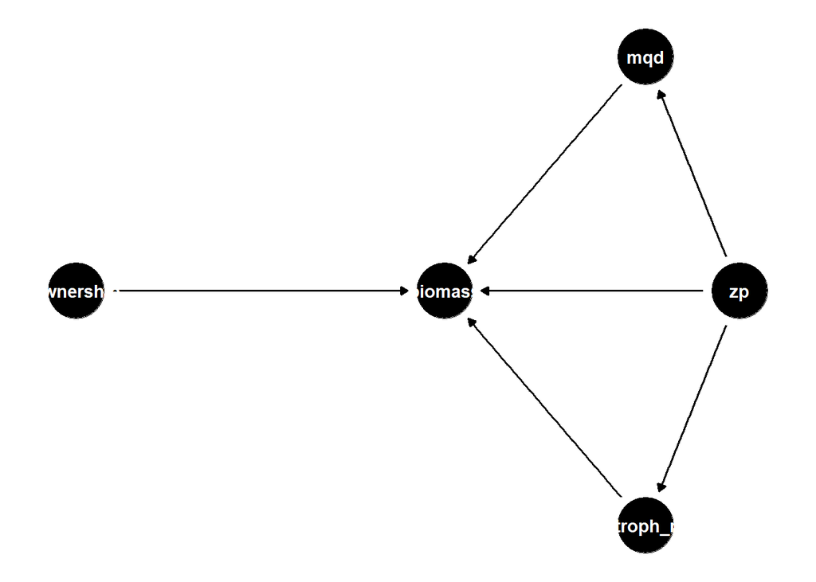

```r
dag <- dagify(
  biomass ~ troph_r + mqd + ownership + zp,
  troph_r ~ zp,
  mqd ~ zp,
  exposure = "troph_r",
  outcome = "biomass"
)

ggdag(dag) +
  theme_dag()
```

The adjustment set for estimating the effect of `troph_r` on biomass is:

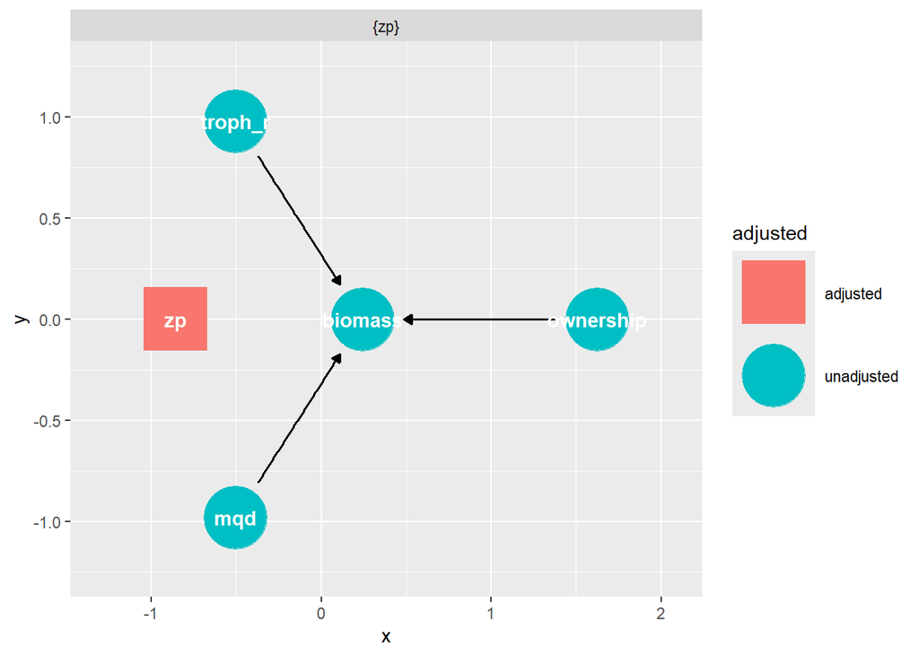

```r
ggdag_adjustment_set(dag, exposure = "troph_r", outcome = "biomass")
```

The key point is that `mqd` is not a confounder because it is essentially uncorrelated with `troph_r`; it can nevertheless be included as a precision covariable.

# 3 P-hacking

The simulated dataset contains independent random variables, so there is no real relationship between `biomass` and the predictors.

```r
set.seed(1)

dat <- data.frame(matrix(rnorm(3000), ncol = 10))

colnames(dat) <- c(
  "biomass", "fertility", "tmen", "tmax", "tmin",
  "prec_summer", "tree_height", "latitude",
  "longitude", "manag_intensity"
)
```

A model fitted to all variables will generally contain no real effects:

```r
summary(
  lm(
    biomass ~ fertility + tmen + tmax + tmin +
      prec_summer + tree_height + latitude +
      longitude + manag_intensity,
    data = dat
  )
)
```

```
Call:
lm(formula = biomass ~ fertility + tmen + tmax + tmin + prec_summer +
    tree_height + latitude + longitude + manag_intensity, data = dat)

Residuals:
     Min       1Q   Median       3Q      Max
-2.97169 -0.57536 -0.01913  0.62865  2.53110

Coefficients:
                Estimate Std. Error t value Pr(>|t|)
(Intercept)      0.03958    0.05688   0.696    0.487
fertility        0.01554    0.05527   0.281    0.779
tmen             0.04149    0.05309   0.781    0.435
tmax            -0.01237    0.05553  -0.223    0.824
tmin            -0.07066    0.05699  -1.240    0.216
prec_summer      0.02318    0.05380   0.431    0.667
tree_height      0.01101    0.05365   0.205    0.838
latitude        -0.02454    0.05614  -0.437    0.662
longitude       -0.02141    0.05906  -0.363    0.717
manag_intensity  0.03154    0.05275   0.598    0.550

Residual standard error: 0.9737 on 290 degrees of freedom
Multiple R-squared:  0.00983,   Adjusted R-squared:  -0.0209
F-statistic: 0.3199 on 9 and 290 DF,  p-value: 0.9682
```

However, if many different subsets, transformations or interactions are tried and only the models producing small p-values are retained, apparently significant effects can be obtained by chance.

This is **p-hacking**: the final p-values no longer have their nominal interpretation because the model was selected using the same data and the same significance criterion.